# Multiple Regression Analysis

Priscilla Hartono

10/14/2016

*Source file* ⇒ report.Rmd

## Abstract

This paper is the third homework of STAT 159, Reproducible and Collaborative Statistical Data Science, taught by Professor Gaston Sanchez in the fall of 2016 at UC Berkeley.

In this paper we reproduce the analysis in section 3.2, *Multiple Linear Regression*, of the book [**An Introduction to Statistical Learning**](http://www-bcf.usc.edu/~gareth/ISL/) (by James et al) using dataset, [**Advertising.csv**](http://www-bcf.usc.edu/~gareth/ISL/Advertising.csv).

## Introduction

In the real world, when predicting a response, we want to take into account all possible predictors. So far we know how to take a simple regression analysis of a single predictor variable. Now, we want to make more meaningful analysis by including multiple predictors, doing a multiple linear regression. It accomodates multiple predictors by giving each a separate slope coefficient in a single model.

## Data

The dataset we used in this paper is Advertising.csv. It contains 200 entries of different markets’ marketing budget through each media medium (TV, Radio, Newspaper) and how many units were sold.

*Sales in thousands of units. Budgets in thousands of dollars*

For this paper, we used all the variables: TV, Radio, Newspaper, and Sales. The numbers under TV, Radio, and Newspaper refers to how much budget was put into advertising by each, and the number under Sales reflects the number of units sold in that particular market.

Before we start doing the regressions, we want to look at how our data look like through histograms and simple regression.

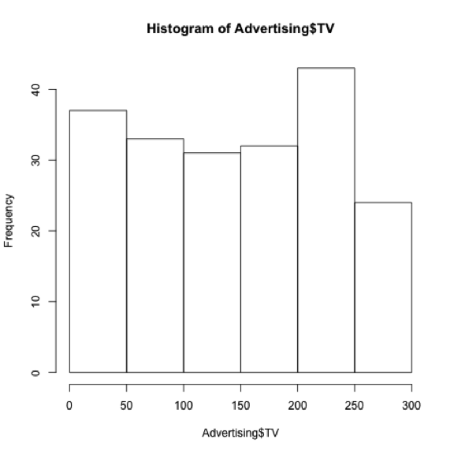

Histogram of TV

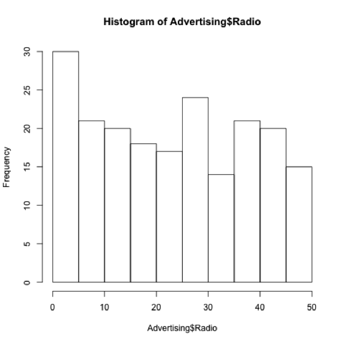

Histogram of Radio

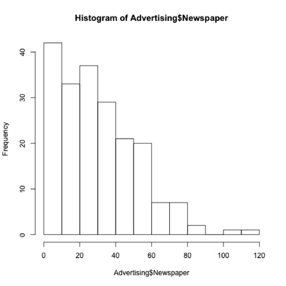

Histogram of Newspaper

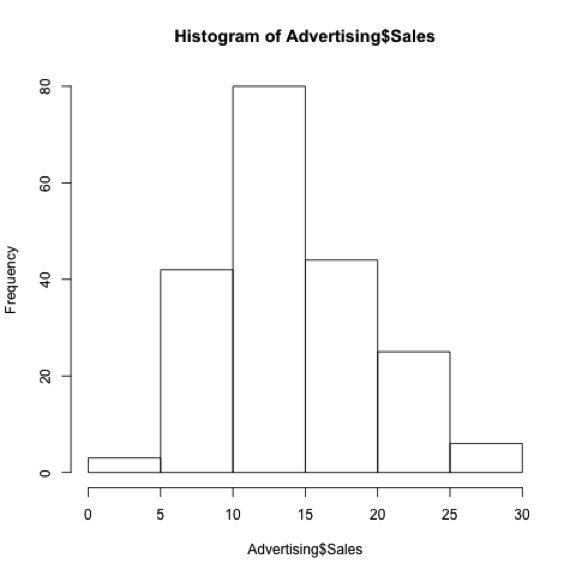

Histogram of Sales

## Methodology

The multiple linear regression model takes the form
$$Y = \beta_0 + \beta_1X_1 + \beta_2X_2 + ... + \beta_pX_p + \epsilon$$
and for this dataset,
$$sales = \beta_0 + \beta_1 * TV + \beta_2 * Radio + \beta_3 * Newspaper + \epsilon$$

## Results

To have a general idea of the relationship between each predictor and target, we want to analyze the scatterplot and matrix.

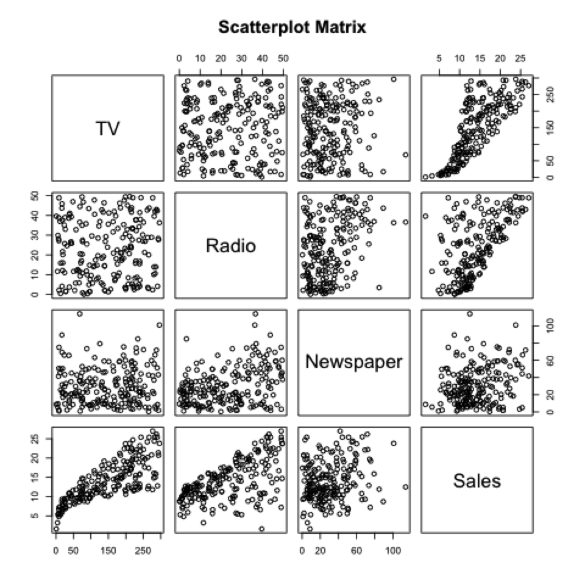

Scatterplot Matrix

Correlation Matrix

|  | X | TV | Radio | Newspaper | Sales |
| --- | --- | --- | --- | --- | --- |
| **X** | 1 | 0.01771 | -0.1107 | -0.1549 | -0.05162 |
| **TV** | 0.01771 | 1 | 0.05481 | 0.05665 | 0.7822 |
| **Radio** | -0.1107 | 0.05481 | 1 | 0.3541 | 0.5762 |
| **Newspaper** | -0.1549 | 0.05665 | 0.3541 | 1 | 0.2283 |
| **Sales** | -0.05162 | 0.7822 | 0.5762 | 0.2283 | 1 |

[figure not shown]

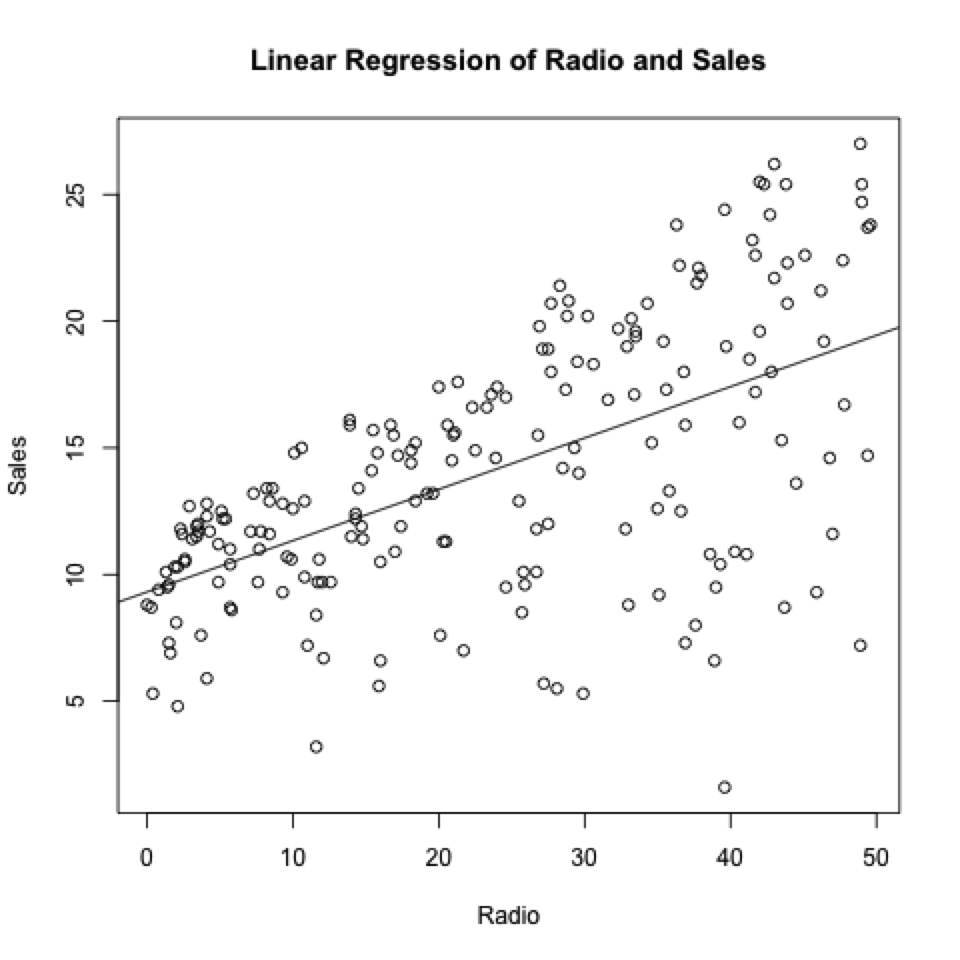

Scatterplot Radio and Sales

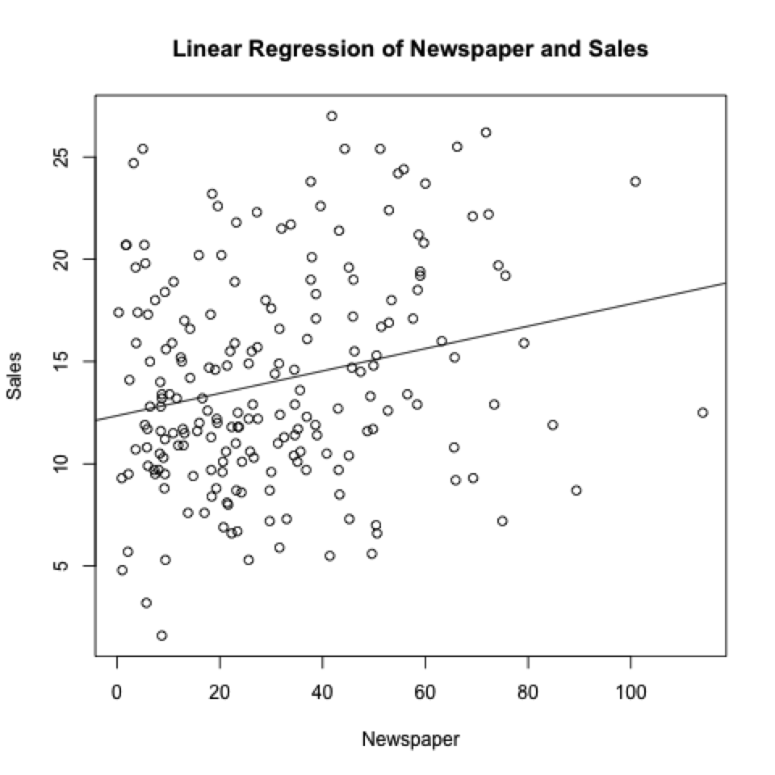

Scatterplot Newspaper and Sales